# The Milwaukee Bucks: 1997 - 2020

## Kayleigh Baasch

### March 31, 2023

The following report will display multiple animated graphics that show the Milwaukee Buck’s shot data from 1997 to 2020.

It should be noted that in each of the graphics, and through the analyses, each season will be referred to as a single year. For example, the 2019-20 season will be referred to as 2020, the 2018-19 will be referred to as 2019, etc.

## A Brief Analysis of the Total Shots Attempted Each Year by the Milwaukee Bucks

The following graphics show the shots taken by the Milwaukee Bucks each season, from 1997 to 2020, based on location and whether they were “Made” or “Missed”, displayed on a half-court (left graphic) and the amount of shots that were “Made” and “Missed” (right graphic).

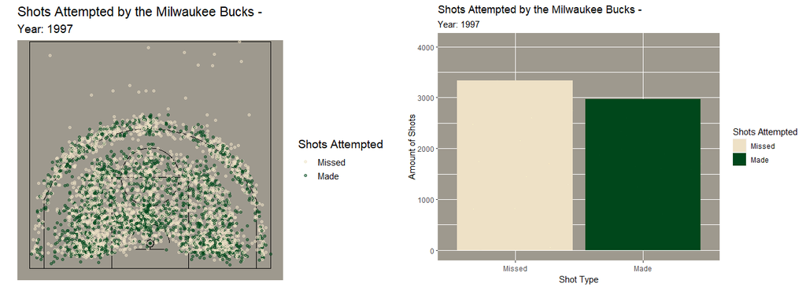

- In each of the graphics, the points or bar displayed in the graphic that are colored tan represent ‘Missed’ shots.
  - The points or bar displayed in the graphic that are colored green represent successfully ‘Made’ shots.
- In each year, there are a few shots taken from behind the three-point line and closer to half-court.
  - Note that the majority of these outlier shots are ‘Missed’ shots.
- Regardless of the year, there are always more “Missed” shots than there are “Made” shots.
  - 1999 has the fewest “Missed” and “Made” shots
  - 2013 has the most “Missed” shots
  - 2019 has the most “Made” shots

## A More In-Depth Analysis of the Graphics

As previously stated, the left graphic shows the shots taken by the Milwaukee Bucks from 1997 to 2020 and is presented on a half-court. Each data point represents the location on the court where the shot was attempted. This allows for a viewer to determine where the majority of shots were attempted from on the court each season. The right graphic presents the proportion of “Made” and “Missed” shots in a manner that is easier to understand for a general viewer. Comparing the heights of the bars allow for a viewer to compare the overall amount of “Missed” and “Made” shots from each season. In each of the graphics, the color tan represents “Missed” shots whereas the color green represents “Made” shots.

It should be noted that each of the two graphics presents the same data. The bar graph (right) was created as an easier to interpret graphic for the general viewer to compare the amount of “Missed” and “Made” shots each year whereas the court graph (left) was created to show the location of the shots.

Every year the Bucks attempt to make shots well behind the three point line and closer to half-court, as seen in the left graphic. The majority of these attempted outlier shots are missed shots, but occasionally some of these shots are “Made.” For example, in 2008 there is a “Made” shot that appears very close to half-court. But, the majority of shots attempted are within, along, or slightly behind the three point line.

It should be noted that, regardless of the year, there are always more “Missed” shots than there are “Made” shots. During 1999, the Milwaukee Bucks attempted the fewest amount of shots, and thus this year has the least amount of both “Missed” and “Made” shots when compared to any other year.

Preceding the 1998-99 season, there was an NBA Lockout which subsequently shortened the regular season to 50 games per team. This event explains the lower-than-average amount of shots attempted and points made by the Bucks during the season. As seen in the right graphic, during 1999, the Bucks only had approximately 2000 “Missed” shots and 1700 “Made” shots.

From the right graphic we can also see that during 2013 the Bucks had the most “Missed” shots when compared to any year with over 4000 “Missed” shots. Meanwhile, the Bucks had the most “Made” shots in 2019 with just over 3500 “Made” shots.

## An Additional Analysis of Successfully Made Shots by the Milwaukee Bucks

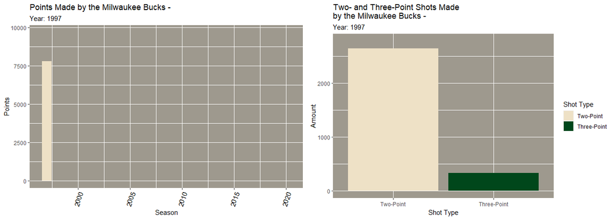

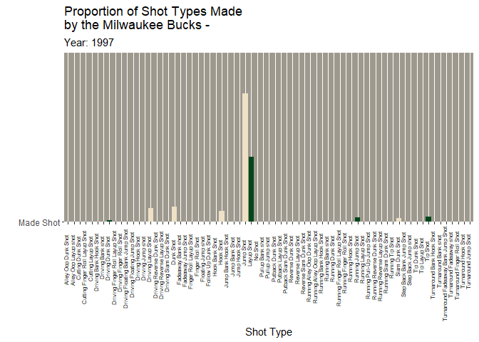

The set of graphics above show a breakdown of the types of shots that were successfully made by the Milwaukee Bucks from 1997-2020. In the first row, the graphics show the total points made each season by the Bucks (left) and the proportion of two-point and three-point shots made each year. The second row shows a more specific comparison of how many shots of each type were made, displaying the different categories of shots recorded in the NBA.

It should be noted that in all three of these graphics the data is representing only shots that were successful made. There is no representation of missed shots in these three graphics.

From the second graphic, we can see that the majority of shots successfully made each year are “Two-Point” shots rather than “Three-Point” shots. Additionally, from the third graphic, we can see that the most successful shot type, across the majority of seasons, is a “Jump Shot”, typically followed by a “Layup Shot.” We can also see that while there are other shot types that typically have a tall enough bar to be noticeable on the graph, such as “Dunk Shot”, “Driving Layup Shot”, or “Hook Shot”, these shots do not have as many successful attempts each season as either “Layup Shot” or “Jump Shot.”